# Lathyrus ms3: Selective agents

# H1 and H2: path model

H1: Flowering phenology of individuals influences the intensities of interactions with seed predators and grazers.

H2: These biotic interactions have important effects on fitness, and alter selection on flowering time within years.

Models include the effects of FFD and n_fl standardized within years (FFD_s_y and n_fl_s_y), grazing and seed predation on fitness relativized within years (fitness_rel_y), as well as the effects of FFD_s_y and n_fl_s_y on grazing and seed predation.

Calculate FFD_s_y, n_fl_s_y and fitness_rel_y:

```r
data_selag<-data_selag%>%
  group_by(year) %>%
  mutate(FFD_mean=mean(FFD,na.rm=T),
         FFD_sd=sd(FFD,na.rm=T),
         FFD_s_y=(FFD-FFD_mean)/FFD_sd,
         n_fl_mean=mean(n_fl,na.rm=T),
         n_fl_sd=sd(n_fl,na.rm=T),
         n_fl_s_y=(n_fl-n_fl_mean)/n_fl_sd,
         fitness_mean=mean(n_intact_seeds,na.rm=T),
         fitness_rel_y=n_intact_seeds/fitness_mean)
```

```r
data_selag$seeds_01<-with(data_selag,ifelse(is.na(n_seeds),NA,
                                              ifelse(n_seeds>0,1,0)))
```

```r
path1_mod1<-glmmTMB(seeds_01~FFD_s_y+n_fl_s_y+grazing_corr+(1|id)+(1|year),
                data=data_selag,family="binomial")
path1_mod2<-glmmTMB(fitness_rel_y~FFD_s_y+n_fl_s_y+grazing_corr+prop_pred_seeds+
                   (1|id)+(1|year),data=data_selag)
path1_mod3<-glmmTMB(grazing_corr~FFD_s_y+n_fl_s_y+(1|id)+(1|year),
                  data=data_selag,family="binomial",weights=grazing_weights)
path1_mod4<-glmmTMB(prop_pred_seeds~FFD_s_y+n_fl_s_y+(1|id)+(1|year),
                  data=data_selag,family="binomial",
                  weights=round(n_seeds))
```

```r
nobs(path1_mod1)
```

```
[1] 2376
```

```r
nobs(path1_mod2)
```

[output not shown]

## Model diagnostics

```r
sim_path1_mod1 <- simulateResiduals(fittedModel = path1_mod1, n = 5000)
sim_path1_mod2 <- simulateResiduals(fittedModel = path1_mod2, n = 5000)
sim_path1_mod3 <- simulateResiduals(fittedModel = path1_mod3, n = 5000)
sim_path1_mod4 <- simulateResiduals(fittedModel = path1_mod4, n = 5000)
```

qq-plot and plot of residuals vs. predicted:

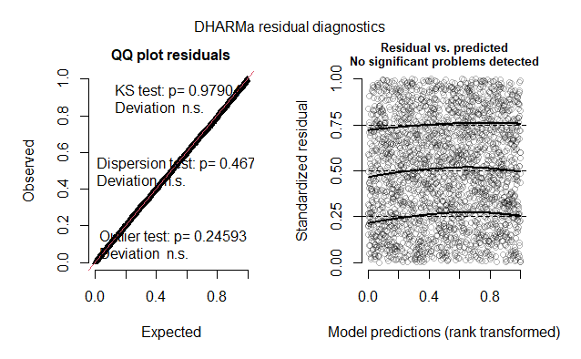

```r
plot(sim_path1_mod1,quantreg=T) # model OK
```

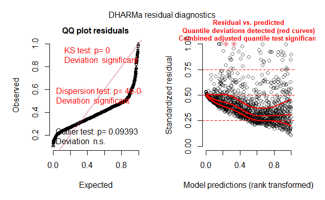

```r
plot(sim_path1_mod2,quantreg=T) # not OK - calculate BCA intervals
```

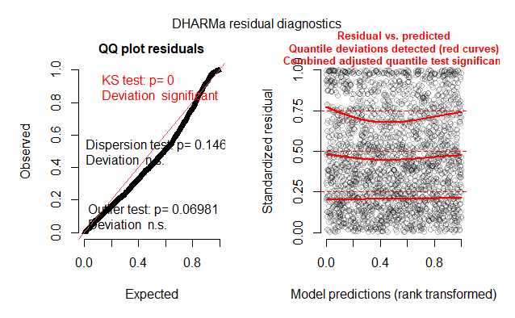

```r
plot(sim_path1_mod3,quantreg=T) # not OK
```

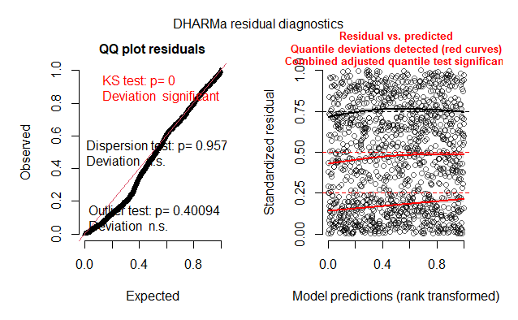

```r
plot(sim_path1_mod4,quantreg=T) # not OK
```

```
    DHARMa nonparametric dispersion test via sd of residuals fitted
    vs. simulated

data:  simulationOutput
ratioObsSim = 0.50412, p-value = 0.1464
alternative hypothesis: two.sided
```

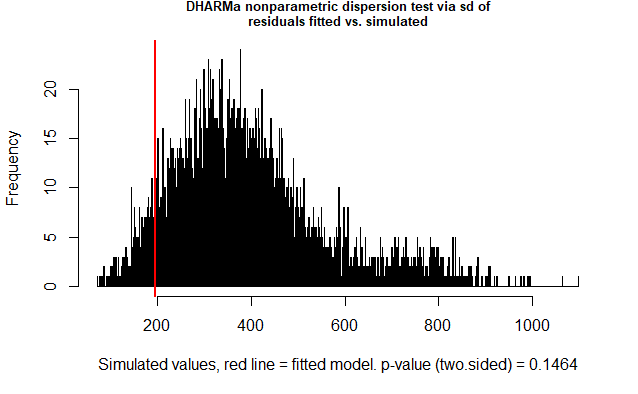

```r
testDispersion(sim_path1_mod3) # OK
```

```
    DHARMa nonparametric dispersion test via sd of residuals fitted
    vs. simulated

data:  simulationOutput
ratioObsSim = 0.99474, p-value = 0.9576
alternative hypothesis: two.sided
```

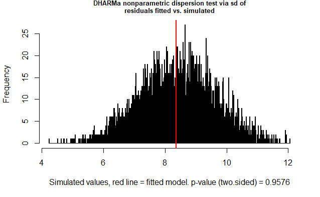

```r
testDispersion(sim_path1_mod4) # OK
```

```
    DHARMa zero-inflation test via comparison to expected zeros with
    simulation under H0 = fitted model


ratioObsSim = 1.1394, p-value < 2.2e-16
alternative hypothesis: two.sided
```

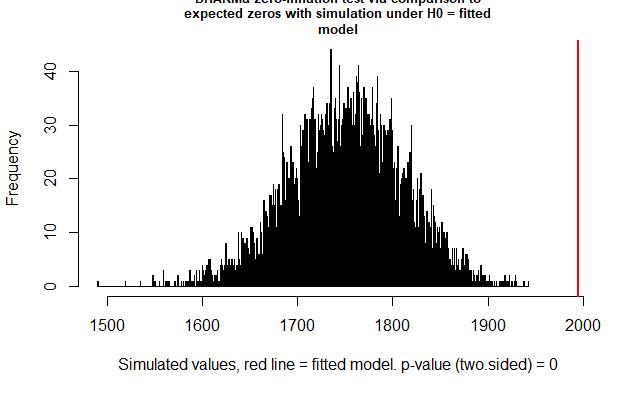

```r
testZeroInflation(sim_path1_mod3) # significant
```

```
    DHARMa zero-inflation test via comparison to expected zeros with
    simulation under H0 = fitted model

data:
ratioObsSim = 1.5119, p-value = 0.0256
alternative hypothesis: two.sided
```

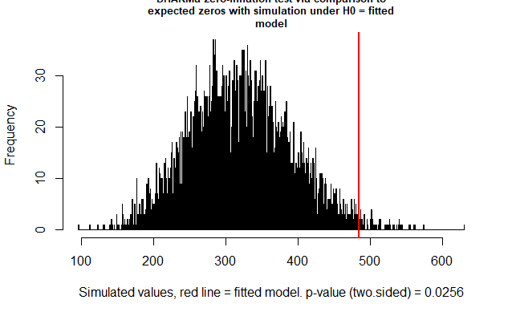

```r
testZeroInflation(sim_path1_mod4) # significant
```

## Refit models 3 and 4 with betabinomial distribution.

```r
path1_mod3_bb<-glmmTMB(grazing_corr~FFD_s_y+n_fl_s_y+(1|id)+(1|year),
                            data=data_selag,family="betabinomial",
                            weights=grazing_weights)
path1_mod4_bb<-glmmTMB(prop_pred_seeds~FFD_s_y+n_fl_s_y+(1|id)+(1|year),
                            data=data_selag,family="betabinomial",
                            weights=round(n_seeds))
```

### Model diagnostics

```r
sim_path1_mod3_bb <- simulateResiduals(fittedModel = path1_mod3_bb, n = 5000)
sim_path1_mod4_bb <- simulateResiduals(fittedModel = path1_mod4_bb, n = 5000)
```

qq-plot and plot of residuals vs. predicted:

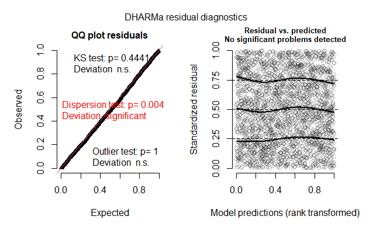

```r
plot(sim_path1_mod3_bb,quantreg=T) # not OK
```

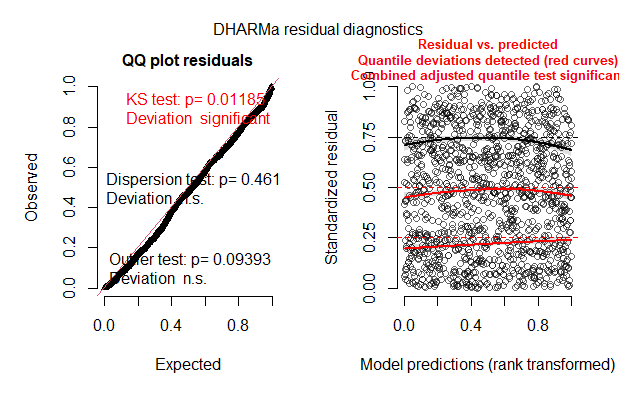

```r
plot(sim_path1_mod4_bb,quantreg=T) # not OK
```

KS test being significant is probably not a problem.

From https://github.com/florianhartig/DHARMa/issues/181

"the p-value shows you that there is a significant deviation from the assumed distribution, but significance != effect size. In other words, if you have a large number of data points (as you have here), even the slightest deviation will become significant. […] the qq-plot is nearly linear, suggesting that the overall distribution is roughly OK.

```
    DHARMa nonparametric dispersion test via sd of residuals fitted
    vs. simulated

data:  simulationOutput
ratioObsSim = 0.30572, p-value = 0.0048
alternative hypothesis: two.sided
```

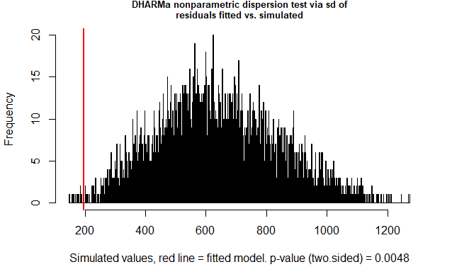

```r
testDispersion(sim_path1_mod3_bb) # a bit of underdispersion, probably OK
```

[output not shown]

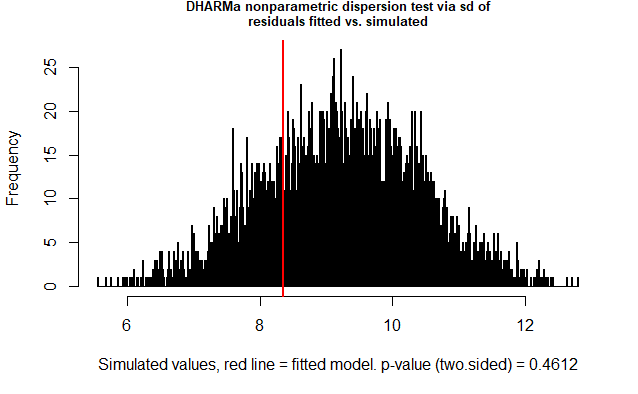

```r
testDispersion(sim_path1_mod4_bb) # OK
```

```
    DHARMa zero-inflation test via comparison to expected zeros with
    simulation under H0 = fitted model

data:  simulationOutput
ratioObsSim = 1.0197, p-value = 0.7276
alternative hypothesis: two.sided
```

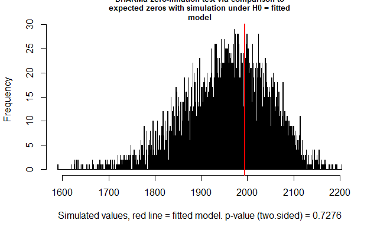

```r
testZeroInflation(sim_path1_mod3_bb) # OK
```

```
    DHARMa zero-inflation test via comparison to expected zeros with
    simulation under H0 = fitted model

data:  simulationOutput
ratioObsSim = 1.1793, p-value = 0.3752
alternative hypothesis: two.sided
```

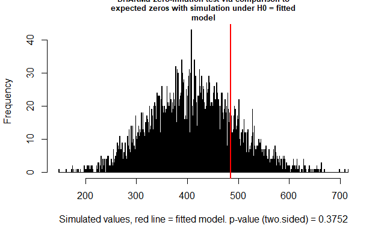

```r
testZeroInflation(sim_path1_mod4_bb) # OK
```

```r
anova(path1_mod3,path1_mod3_bb)
```

```
Data: data_selag
Models:
path1_mod3: grazing_corr ~ FFD_s_y + n_fl_s_y + (1 | id) + (1 | year), zi=~0, disp=~1
path1_mod3_bb: grazing_corr ~ FFD_s_y + n_fl_s_y + (1 | id) + (1 | year), zi=~0, disp=~1
              Df    AIC    BIC logLik deviance  Chisq Chi Df Pr(>Chisq)
path1_mod3     5 155103 155132 -77547   155093
path1_mod3_bb  6   3601   3636  -1795     3589 151504      1  < 2.2e-16 ***
---
Signif. codes:  0 ‘***’ 0.001 ‘**’ 0.01 ‘*’ 0.05 ‘.’ 0.1 ‘ ’ 1
```

```r
anova(path1_mod4,path1_mod4_bb)
```

```
Data: data_selag
Models:
path1_mod4: prop_pred_seeds ~ FFD_s_y + n_fl_s_y + (1 | id) + (1 | year), zi=~0, disp=~1
path1_mod4_bb: prop_pred_seeds ~ FFD_s_y + n_fl_s_y + (1 | id) + (1 | year), zi=~0, disp=~1
              Df    AIC    BIC  logLik deviance  Chisq Chi Df Pr(>Chisq)
path1_mod4     5 6696.0 6721.8 -3343.0   6686.0
path1_mod4_bb  6 4953.5 4984.4 -2470.8   4941.5 1744.5      1  < 2.2e-16

path1_mod4
path1_mod4_bb ***
---
Signif. codes:  0 ‘***’ 0.001 ‘**’ 0.01 ‘*’ 0.05 ‘.’ 0.1 ‘ ’ 1
```

```r
AIC(path1_mod3,path1_mod3_bb)
```

|  | df | AIC |
| --- | --- | --- |
| path1_mod3 | 5 | 155103.361 |
| path1_mod3_bb | 6 | 3601.166 |

```r
AIC(path1_mod4,path1_mod4_bb)
```

|  | df | AIC |
| --- | --- | --- |
| path1_mod4 | 5 | 6695.992 |
| path1_mod4_bb | 6 | 4953.500 |

Use betabinomial models.

Tested quadratic effects of FFD on grazing and seed predation, and they were not significant in betabinomial models.

## Boostrapped confidence intervals for model 2:

### Mixed model

```r
path1_mod2_glmer<-glmer(fitness_rel_y~FFD_s_y+n_fl_s_y+grazing_corr+
                          prop_pred_seeds+(1|id)+(1|year),data=data_selag)
# We need to use glmer for this
```

```r
confint(b_par_1,level=0.95, method="boot") # Percentile method
```

[output not shown]

Similar to significances in the lmer model.

## New path model

```r
summary(path1_mod1)$coefficients
```

```
$cond
               Estimate Std. Error    z value     Pr(>|z|)
(Intercept)   0.5448470 0.21257583   2.563071 1.037508e-02
FFD_s_y      -0.6968366 0.06747741 -10.326961 5.321988e-25
n_fl_s_y      0.6111297 0.07683091   7.954216 1.802689e-15
grazing_corr -3.8250266 0.32225988 -11.869385 1.707182e-32

$zi
NULL

$disp
NULL
```

```r
# std coefs if needed from path1 without random effects
summary(path1_mod2)$coefficients
```

```
$cond
                  Estimate Std. Error    z value     Pr(>|z|)
(Intercept)      4.1866333 0.88694757   4.720271 2.355301e-06
FFD_s_y         -0.1790698 0.06873317  -2.605290 9.179656e-03
n_fl_s_y         0.5868972 0.05766612  10.177505 2.498870e-24
grazing_corr    -1.3597652 0.42561090  -3.194855 1.399010e-03
prop_pred_seeds -3.6442115 0.20386754 -17.875388 1.833937e-71

$zi
NULL

$disp
NULL
```

```r
# get significances from bootstrapped CIs, std coefs from path1 without random effects
summary(path1_mod3_bb)$coefficients
```

```
$cond
              Estimate Std. Error   z value     Pr(>|z|)
(Intercept) -2.9368887 0.32909846 -8.924043 4.495707e-19
FFD_s_y     -0.3479031 0.08335881 -4.173561 2.998753e-05
n_fl_s_y     0.1875620 0.06457848  2.904404 3.679536e-03

$zi
NULL

$disp
NULL
```

```r
# significances and ustd coefs from here, std if needed from path1 without random effects
summary(path1_mod4_bb)$coefficients
```

```
$cond
              Estimate Std. Error   z value     Pr(>|z|)
(Intercept) -0.7491371 0.31175650 -2.402956 1.626315e-02
FFD_s_y      0.1007740 0.05463502  1.844495 6.511103e-02
n_fl_s_y     0.2060346 0.04261941  4.834291 1.336212e-06

$zi
NULL

$disp
NULL
```

```r
# significances and ustd coefs from here, std if needed from path1 without random effects
```

piecewiseSEM does not work with glmmTMB - and that is the only package I found that fits betabinomial mixed models.

```r
path1_norandom<-psem(
  glm(seeds_01~FFD_s_y+n_fl_s_y+grazing_corr,
                data=data_selag,family="binomial"),
  lm(fitness_rel_y~FFD_s_y+n_fl_s_y+grazing_corr+prop_pred_seeds,
               data=data_selag),
  glm(grazing_corr~FFD_s_y+n_fl_s_y,
                  data=data_selag,family="binomial",weights=grazing_weights),
  glm(prop_pred_seeds~FFD_s_y+n_fl_s_y,
                  data=data_selag,family="binomial",
                  weights=n_seeds))
coefs(path1_norandom)
```

| Response | Predictor | Estimate | Std.Error | DF | Crit.Value | P.Value | Std.Estimate |  |
| --- | --- | --- | --- | --- | --- | --- | --- | --- |
| seeds_01 | FFD_s_y | -0.6041 | 0.0559 | 2372 | -10.8057 | 0.0000 | -0.2741 | *** |
| seeds_01 | n_fl_s_y | 0.4999 | 0.0642 | 2372 | 7.7907 | 0.0000 | 0.2268 | *** |
| seeds_01 | grazing_corr | -3.2497 | 0.2395 | 2372 | -13.5712 | 0.0000 | -0.4572 | *** |
| fitness_rel_y | FFD_s_y | -0.2054 | 0.0881 | 1276 | -2.3322 | 0.0198 | -0.0965 | * |
| fitness_rel_y | n_fl_s_y | 0.4506 | 0.0726 | 1276 | 6.2070 | 0.0000 | 0.2118 | *** |
| fitness_rel_y | grazing_corr | 0.6428 | 0.5272 | 1276 | 1.2192 | 0.2230 | 0.0937 |  |
| fitness_rel_y | prop_pred_seeds | -1.6647 | 0.1931 | 1276 | -8.6187 | 0.0000 | -0.2859 | *** |
| grazing_corr | FFD_s_y | -0.1169 | 0.0054 | 2350 | -21.5365 | 0.0000 | -0.0641 | *** |
| grazing_corr | n_fl_s_y | -0.0692 | 0.0033 | 2350 | -20.7038 | 0.0000 | -0.0379 | *** |
| prop_pred_seeds | FFD_s_y | -0.0330 | 0.0208 | 1278 | -1.5837 | 0.1133 | -0.0181 |  |

[output cut: 1 more lines]

```r
plot(path1_norandom)
```

[interactive chart not shown]

Figure 1: Path diagram (made in Inkscape)

% of grazed plants that produced seeds

```r
nrow(subset(data_selag,grazing_corr>0&n_seeds>0))*100/
  nrow(subset(data_selag,grazing_corr>0))
```

```
[1] 28.63341
```

% of plants with more than half of their above-ground structures removed that produced seeds

```r
nrow(subset(data_selag,grazing_corr>0.5&n_seeds>0))*100/
  nrow(subset(data_selag,grazing_corr>0))
```

```
[1] 6.290672
```

Only 29% of plants that experienced any grazing produced seeds, and 6% of plants that had more than half of their above-ground structures removed.

# H3

H3: Variation in climatic conditions during spring among years causes differences in selection on flowering time, through effects mediated by the intensity of biotic interactions.

# H3 - Part 1

Variation in climatic conditions during spring among years influences the intensity of biotic interactions and the covariance between interaction intensity and plant phenology.

First, models to test the effect of spring temperatures on antagonistic interactions, while accounting for FFD and number of flowers. Using FFD and number of flowers standardized within years, temperatures standardized across years. Including interactions among FFD and temperatures. NOT including a random effect of year because there is only one value of temperature for each year.

## Grazing

```r
mod_grazing<-glmmTMB(cbind(grazing_success,grazing_failure)~
                     (scale(mean_3)+scale(mean_4)+scale(mean_5))*FFD_s_y+
                     n_fl_s_y+(1|id),data = data_selag,
                   family="binomial")
summary(mod_grazing)
```

[output not shown]

### Model diagnostics

Simulate residuals of the model:

```r
sim_mod_grazing <- simulateResiduals(fittedModel=mod_grazing,n=5000)
```

qq-plot and plot of residuals vs. predicted:

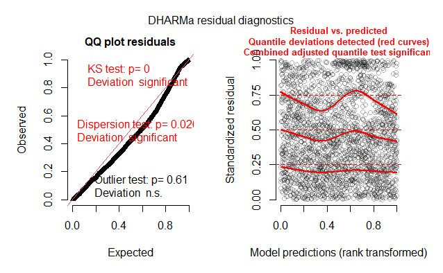

```r
plot(sim_mod_grazing,quantreg=T)
```

```
    DHARMa nonparametric dispersion test via sd of residuals fitted
    vs. simulated

data:  simulationOutput
ratioObsSim = 0.41949, p-value = 0.026
alternative hypothesis: two.sided
```

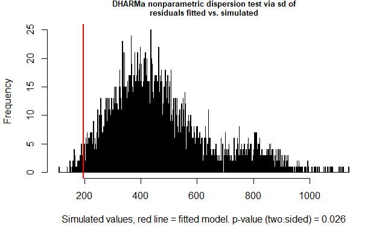

```r
testDispersion(sim_mod_grazing)
```

Slightly underdispersed.

```
    DHARMa zero-inflation test via comparison to expected zeros with
    simulation under H0 = fitted model

data:  simulationOutput
ratioObsSim = 1.1381, p-value < 2.2e-16
alternative hypothesis: two.sided
```

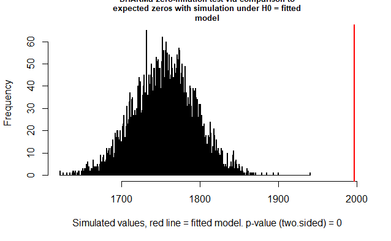

```r
testZeroInflation(sim_mod_grazing)
```

Test of zero inflation is significant.

### Try with betabinomial

```r
mod_grazing_bb<-glmmTMB(cbind(grazing_success,grazing_failure)~
                       (scale(mean_3)+scale(mean_4)+scale(mean_5))*FFD_s_y+
                       n_fl_s_y+(1|id),data = data_selag,
                     family="betabinomial")
summary(mod_grazing_bb)
```

[output not shown]

### Model diagnostics

Simulate residuals of the model:

```r
sim_mod_grazing_bb <- simulateResiduals(fittedModel=mod_grazing_bb,n=5000)
```

qq-plot and plot of residuals vs. predicted:

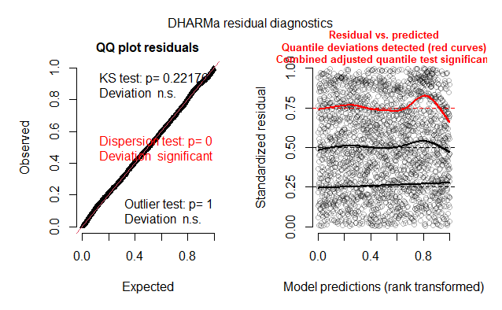

```r
plot(sim_mod_grazing_bb,quantreg=T)
```

[output not shown]

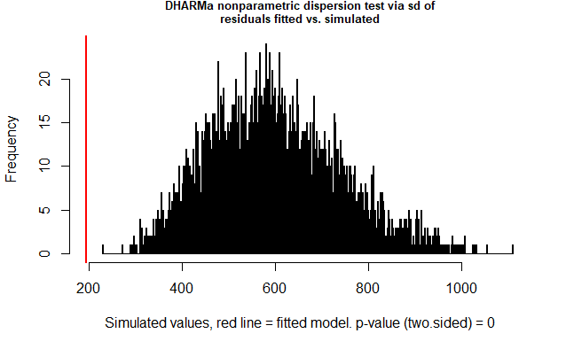

```r
testDispersion(sim_mod_grazing_bb)
```

Still underdispersion.

[output not shown]

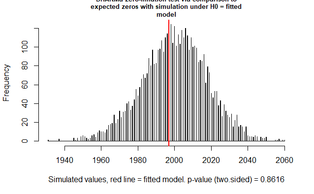

```r
testZeroInflation(sim_mod_grazing_bb)
```

But zero inflation is fixed

```r
anova(mod_grazing,mod_grazing_bb)
```

```
Data: data_selag
Models:
mod_grazing: cbind(grazing_success, grazing_failure) ~ (scale(mean_3) + scale(mean_4) + , zi=~0, disp=~1
mod_grazing:     scale(mean_5)) * FFD_s_y + n_fl_s_y + (1 | id), zi=~0, disp=~1
mod_grazing_bb: cbind(grazing_success, grazing_failure) ~ (scale(mean_3) + scale(mean_4) + , zi=~0, disp=~1
mod_grazing_bb:     scale(mean_5)) * FFD_s_y + n_fl_s_y + (1 | id), zi=~0, disp=~1
               Df    AIC    BIC logLik deviance  Chisq Chi Df Pr(>Chisq)
mod_grazing    10 174951 175008 -87465   174931
mod_grazing_bb 11   4014   4077  -1996     3992 170939      1  < 2.2e-16

mod_grazing
mod_grazing_bb ***
---
Signif. codes:  0 ‘***’ 0.001 ‘**’ 0.01 ‘*’ 0.05 ‘.’ 0.1 ‘ ’ 1
```

```r
AIC(mod_grazing,mod_grazing_bb)
```

|  | df | AIC |
| --- | --- | --- |
| mod_grazing | 10 | 174950.700 |
| mod_grazing_bb | 11 | 4013.658 |

Keep mod_grazing_bb.

## Seed predation

```r
mod_seedpred<-glmmTMB(cbind(round(n_pred_seeds),round(n_intact_seeds))~
                     (scale(mean_3)+scale(mean_4)+scale(mean_5)+scale(mean_6))*
                      FFD_s_y+n_fl_s_y+(1|id),data=subset(data_selag,n_seeds>0),
                    family="binomial")
summary(mod_seedpred)
```

[output not shown]

### Model diagnostics

Simulate residuals of the model:

```r
sim_mod_seedpred <- simulateResiduals(fittedModel=mod_seedpred,n=5000)
```

qq-plot and plot of residuals vs. predicted:

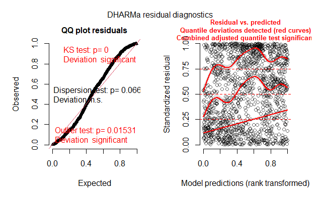

```r
plot(sim_mod_seedpred,quantreg=T)
```

```
    DHARMa nonparametric dispersion test via sd of residuals fitted
    vs. simulated

data:  simulationOutput
ratioObsSim = 1.1495, p-value = 0.0668
alternative hypothesis: two.sided
```

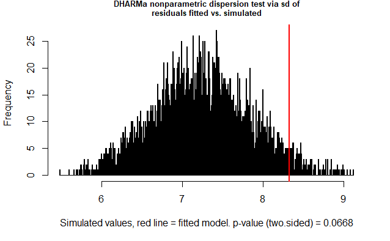

```r
testDispersion(sim_mod_seedpred)
```

OK.

```
    DHARMa zero-inflation test via comparison to expected zeros with
    simulation under H0 = fitted model

data:  simulationOutput
ratioObsSim = 1.3914, p-value < 2.2e-16
```

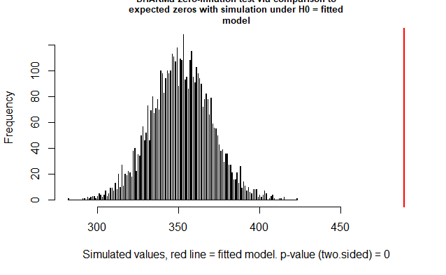

```r
testZeroInflation(sim_mod_seedpred)
```

Zero inflation.

### Try with betabinomial

```r
mod_seedpred_bb<-glmmTMB(cbind(round(n_pred_seeds),round(n_intact_seeds))~
                     (scale(mean_3)+scale(mean_4)+scale(mean_5)+scale(mean_6))*
                      FFD_s_y+n_fl_s_y+(1|id),data=subset(data_selag,n_seeds>0),
                    family="betabinomial")
summary(mod_seedpred_bb)
```

[output not shown]

### Model diagnostics

Simulate residuals of the model:

```r
sim_mod_seedpred_bb <- simulateResiduals(fittedModel=mod_seedpred_bb,n=5000)
```

qq-plot and plot of residuals vs. predicted:

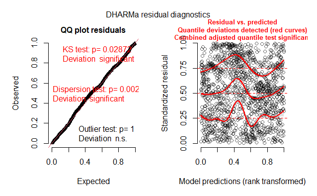

```r
plot(sim_mod_seedpred_bb,quantreg=T)
```

```
    DHARMa nonparametric dispersion test via sd of residuals fitted
    vs. simulated

data:  simulationOutput
ratioObsSim = 0.85972, p-value = 0.0024
alternative hypothesis: two.sided
```

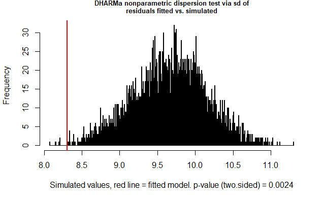

```r
testDispersion(sim_mod_seedpred_bb)
```

Slight underdispersion.

```
    DHARMa zero-inflation test via comparison to expected zeros with
    simulation under H0 = fitted model

data:  simulationOutput
ratioObsSim = 1.0244, p-value = 0.4808
alternative hypothesis: two.sided
```

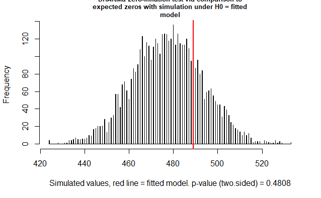

```r
testZeroInflation(sim_mod_seedpred_bb)
```

OK.

```r
anova(mod_seedpred,mod_seedpred_bb)
```

[output not shown]

```r
AIC(mod_seedpred,mod_seedpred_bb)
```

|  | df | AIC |
| --- | --- | --- |
| mod_seedpred | 12 | 9018.873 |
| mod_seedpred_bb | 13 | 5339.232 |

Keep mod_seedpred_bb.

## Table 1

```r
kable(summary(mod_grazing_bb)$coefficients,digits=c(3,3,2,3))
```

|  | Estimate | Std. Error | z value | Pr(>\|z\|) |
| --- | --- | --- | --- | --- |
| (Intercept) | -2.232 | 0.090 | -24.66 | 0.000 |
| scale(mean_3) | 0.504 | 0.067 | 7.52 | 0.000 |
| scale(mean_4) | -0.333 | 0.064 | -5.19 | 0.000 |
| scale(mean_5) | -0.440 | 0.086 | -5.10 | 0.000 |
| FFD_s_y | -0.256 | 0.073 | -3.50 | 0.000 |
| n_fl_s_y | 0.159 | 0.059 | 2.70 | 0.007 |
| scale(mean_3):FFD_s_y | 0.107 | 0.072 | 1.49 | 0.136 |
| scale(mean_4):FFD_s_y | -0.128 | 0.066 | -1.95 | 0.052 |
| scale(mean_5):FFD_s_y | 0.022 | 0.089 | 0.24 | 0.807 |

[output not shown]

[output not shown]

```r
kable(summary(mod_seedpred_bb)$coefficients,digits=c(3,3,2,3))
```

|  | Estimate | Std. Error | z value | Pr(>\|z\|) |
| --- | --- | --- | --- | --- |
| (Intercept) | -0.843 | 0.055 | -15.29 | 0.000 |
| scale(mean_3) | -0.202 | 0.072 | -2.79 | 0.005 |
| scale(mean_4) | 0.030 | 0.062 | 0.48 | 0.632 |
| scale(mean_5) | 0.469 | 0.072 | 6.49 | 0.000 |
| scale(mean_6) | 0.415 | 0.062 | 6.69 | 0.000 |
| FFD_s_y | 0.031 | 0.059 | 0.54 | 0.592 |
| n_fl_s_y | 0.178 | 0.044 | 4.03 | 0.000 |
| scale(mean_3):FFD_s_y | 0.174 | 0.082 | 2.13 | 0.033 |
| scale(mean_4):FFD_s_y | -0.159 | 0.067 | -2.38 | 0.017 |
| scale(mean_5):FFD_s_y | 0.025 | 0.078 | 0.32 | 0.746 |
| scale(mean_6):FFD_s_y | -0.094 | 0.068 | -1.37 | 0.170 |

[output not shown]

[output not shown]

## Graphs for Fig 2 - Part 1

```r
pred_grazing_mean3<-ggpredict(mod_grazing_bb,
                              terms = c("mean_3 [all]"))
pred_grazing_mean4<-ggpredict(mod_grazing_bb,
                              terms = c("mean_4 [all]"))
pred_grazing_mean5<-ggpredict(mod_grazing_bb,
                              terms = c("mean_5 [all]"))
```

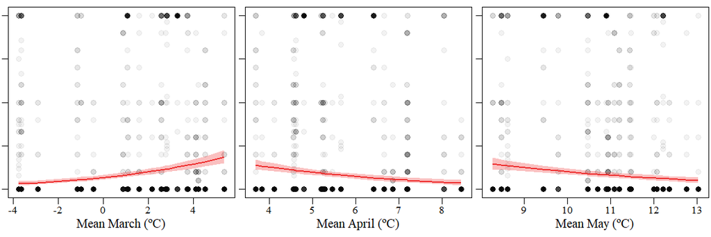

```r
Fig_2_temps_grazing<-grid.arrange(
  ggplot(data_selag,aes(x=mean_3,y=grazing_corr))+
    geom_point(size=3,alpha=0.05)+
    geom_ribbon(data=pred_grazing_mean3,
                aes(x,predicted,ymin=conf.low,ymax=conf.high),
                fill="firebrick2",alpha=0.3)+
    geom_line(data=pred_grazing_mean3,aes(x,predicted),
              color="firebrick2",size=1)+
    my_theme()+xlab("Mean March (ºC)")+ylab(NULL)+
    theme(plot.margin = unit(c(0.3,0.1,0.3,0.1), "cm"))+
    theme(axis.text.y=element_blank()),
  ggplot(data_selag,aes(x=mean_4,y=grazing_corr))+
    geom_point(size=3,alpha=0.05)+
    geom_ribbon(data=pred_grazing_mean4,
                aes(x,predicted,ymin=conf.low,ymax=conf.high),
                fill="firebrick2",alpha=0.3)+
    geom_line(data=pred_grazing_mean4,aes(x,predicted),
              color="firebrick2",size=1)+
    my_theme()+xlab("Mean April (ºC)")+ylab(NULL)+
    theme(plot.margin = unit(c(0.3,0.1,0.3,0.1), "cm"))+
    theme(axis.text.y=element_blank()),
  ggplot(data_selag,aes(x=mean_5,y=grazing_corr))+
    geom_point(size=3,alpha=0.05)+
    geom_ribbon(data=pred_grazing_mean5,
                aes(x,predicted,ymin=conf.low,ymax=conf.high),
                fill="firebrick2",alpha=0.3)+
    geom_line(data=pred_grazing_mean5,aes(x,predicted),
              color="firebrick2",size=1)+
    my_theme()+xlab("Mean May (ºC)")+ylab(NULL)+
    theme(plot.margin = unit(c(0.3,0.1,0.3,0.1), "cm"))+
    theme(axis.text.y=element_blank()),
  ncol=3)
```

```r
ggsave(filename="output/figures/Fig_2_temps_grazing.tiff",
       plot=Fig_2_temps_grazing,device="tiff",width=15,height=8,units="cm",
       dpi=300,compression="lzw")
```

```r
pred_seedpred_mean3_FFD<-ggpredict(mod_seedpred_bb,
                        terms = c("mean_3 [all]","FFD_s_y [-2.6:3.9 by=.5]"))
pred_seedpred_mean4_FFD<-ggpredict(mod_seedpred_bb,
                        terms = c("mean_4 [all]","FFD_s_y [-2.6:3.9 by=.5]"))
pred_seedpred_mean5<-ggpredict(mod_seedpred_bb,
                              terms = c("mean_5 [all]"))
pred_seedpred_mean6<-ggpredict(mod_seedpred_bb,
                              terms = c("mean_6 [all]"))
```

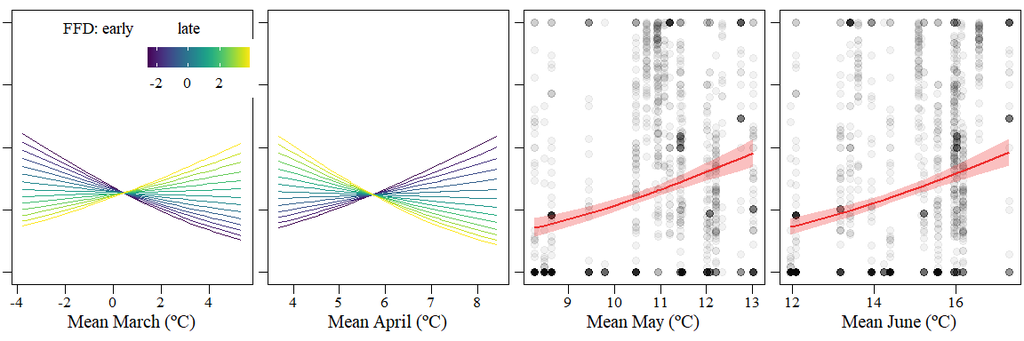

```r
Fig_2_temps_seedpred<-grid.arrange(
  ggplot(pred_seedpred_mean3_FFD,aes(x,predicted,colour=group,fill=group))+
    geom_line(aes(color=as.numeric(as.character(group))),size=0.6)+my_theme()+
    scale_color_viridis()+
    scale_y_continuous(breaks = seq(0, 1, by = 0.25))+ylim(0,1)+
    theme(legend.justification=c(1.1,0.99),legend.position=c(1.07,0.89),
        legend.direction="horizontal",legend.title=element_blank())+
    annotate("text",x=0.8,y=0.98,label="FFD: early          late",
             family="serif",size=5)+
    xlab("Mean March (ºC)")+ylab(NULL)+
    theme(plot.margin = unit(c(0.3,0.1,0.3,0.1), "cm")),
  ggplot(pred_seedpred_mean4_FFD,aes(x,predicted,colour=group,fill=group))+
    geom_line(aes(color=as.numeric(as.character(group))),size=0.6)+my_theme()+
    scale_color_viridis()+
    theme(axis.text.y=element_blank())+
    scale_y_continuous(breaks = seq(0, 1, by = 0.25))+ylim(0,1)+
    xlab("Mean April (ºC)")+ylab(NULL)+
    theme(plot.margin = unit(c(0.3,0.1,0.3,0.1), "cm")),
  ggplot(data_selag,aes(x=mean_5,y=prop_pred_seeds))+
    geom_point(size=3,alpha=0.05)+
    geom_ribbon(data=pred_seedpred_mean5,
                aes(x,predicted,ymin=conf.low,ymax=conf.high),
                fill="firebrick2",alpha=0.3)+
    geom_line(data=pred_seedpred_mean5,aes(x,predicted),
              color="firebrick2",size=1)+
    my_theme()+xlab("Mean May (ºC)")+ylab(NULL)+
    theme(plot.margin = unit(c(0.3,0.1,0.3,0.1), "cm"))+
    theme(axis.text.y=element_blank()),
  ggplot(data_selag,aes(x=mean_6,y=prop_pred_seeds))+
    geom_point(size=3,alpha=0.05)+
    geom_ribbon(data=pred_seedpred_mean6,
                aes(x,predicted,ymin=conf.low,ymax=conf.high),
                fill="firebrick2",alpha=0.3)+
    geom_line(data=pred_seedpred_mean6,aes(x,predicted),
              color="firebrick2",size=1)+
    my_theme()+xlab("Mean June (ºC)")+ylab(NULL)+
    theme(plot.margin = unit(c(0.3,0.1,0.3,0.1), "cm"))+
    theme(axis.text.y=element_blank()),
  ncol=4)
```

```r
ggsave(filename="output/figures/Fig_2_temps_seedpred.tiff",
       plot=Fig_2_temps_seedpred,device="tiff",width=20,height=8,units="cm",
       dpi=300,compression="lzw")
```